# Identifying Crocodiles Using Classification

### Author: Adrian Khlim

```python
import pandas as pd
import seaborn as sns
import matplotlib.pyplot as plt
```

```python
crocodile_data = pd.read_csv("crocodile_dataset.csv")
```

```python
crocodile_data.head()
```

|  | Observation ID | Common Name | Scientific Name | Family | Genus | Observed Length (m) | Observed Weight (kg) | Age Class | Sex | Date of Observation | Country/Region | Habitat Type | Conservation Status | Observer Name | Notes |
| --- | --- | --- | --- | --- | --- | --- | --- | --- | --- | --- | --- | --- | --- | --- | --- |
| 0 | 1 | Morelet's Crocodile | Crocodylus moreletii | Crocodylidae | Crocodylus | 1.90 | 62.0 | Adult | Male | 31-03-2018 | Belize | Swamps | Least Concern | Allison Hill | Cause bill scientist nation opportunity. |
| 1 | 2 | American Crocodile | Crocodylus acutus | Crocodylidae | Crocodylus | 4.09 | 334.5 | Adult | Male | 28-01-2015 | Venezuela | Mangroves | Vulnerable | Brandon Hall | Ago current practice nation determine operatio... |
| 2 | 3 | Orinoco Crocodile | Crocodylus intermedius | Crocodylidae | Crocodylus | 1.08 | 118.2 | Juvenile | Unknown | 07-12-2010 | Venezuela | Flooded Savannas | Critically Endangered | Melissa Peterson | Democratic shake bill here grow gas enough ana... |
| 3 | 4 | Morelet's Crocodile | Crocodylus moreletii | Crocodylidae | Crocodylus | 2.42 | 90.4 | Adult | Male | 01-11-2019 | Mexico | Rivers | Least Concern | Edward Fuller | Officer relate animal direction eye bag do. |
| 4 | 5 | Mugger Crocodile (Marsh Crocodile) | Crocodylus palustris | Crocodylidae | Crocodylus | 3.75 | 269.4 | Adult | Unknown | 15-07-2019 | India | Rivers | Vulnerable | Donald Reid | Class great prove reduce raise author play mov... |

Checking my features (columns)

```python
crocodile_data.columns
```

```
Index(['Observation ID', 'Common Name', 'Scientific Name', 'Family', 'Genus',
       'Observed Length (m)', 'Observed Weight (kg)', 'Age Class', 'Sex',
       'Date of Observation', 'Country/Region', 'Habitat Type',
       'Conservation Status', 'Observer Name', 'Notes'],
      dtype='object')
```

```python
print("\n".join([col for col in crocodile_data.columns]))
```

```
Observation ID
Common Name
Scientific Name
Family
Genus
Observed Length (m)
Observed Weight (kg)
Age Class
Sex
Date of Observation
Country/Region
Habitat Type
Conservation Status
Observer Name
Notes
```

I noticed we have meters and kilograms, so I will convert these into feet and pounds for my American brain to better visualize and understand.

```python
crocodile_data["Observed Length (ft)"] = crocodile_data["Observed Length (m)"] * 3.28084
```

```python
crocodile_data["Observed Weight (lbs)"] = crocodile_data["Observed Weight (kg)"] * 2.20462
```

```python
crocodile_data.isnull().sum()
```

```
Observation ID           0
Common Name              0
Scientific Name          0
Family                   0
Genus                    0
Observed Length (m)      0
Observed Weight (kg)     0
Age Class                0
Sex                      0
Date of Observation      0
Country/Region           0
Habitat Type             0
Conservation Status      0
Observer Name            0
Notes                    0
Observed Length (ft)     0
Observed Weight (lbs)    0
dtype: int64
```

```python
crocodile_data.dtypes
```

```
Observation ID             int64
Common Name               object
Scientific Name           object
Family                    object
Genus                     object
Observed Length (m)      float64
Observed Weight (kg)     float64
Age Class                 object
Sex                       object
Date of Observation       object
Country/Region            object
Habitat Type              object
Conservation Status       object
Observer Name             object
Notes                     object
Observed Length (ft)     float64
Observed Weight (lbs)    float64
dtype: object
```

```python
crocodile_data.describe()
```

|  | Observation ID | Observed Length (m) | Observed Weight (kg) | Observed Length (ft) | Observed Weight (lbs) |
| --- | --- | --- | --- | --- | --- |
| count | 1000.000000 | 1000.000000 | 1000.000000 | 1000.000000 | 1000.000000 |
| mean | 500.500000 | 2.415110 | 155.771900 | 7.923589 | 343.417846 |
| std | 288.819436 | 1.097542 | 175.186788 | 3.600861 | 386.220297 |
| min | 1.000000 | 0.140000 | 4.400000 | 0.459318 | 9.700328 |
| 25% | 250.750000 | 1.637500 | 53.225000 | 5.372375 | 117.340899 |
| 50% | 500.500000 | 2.430000 | 100.600000 | 7.972441 | 221.784772 |
| 75% | 750.250000 | 3.010000 | 168.875000 | 9.875328 | 372.305203 |
| max | 1000.000000 | 6.120000 | 1139.700000 | 20.078741 | 2512.605414 |

I want to classify based on any statistical data, what kind of crocodile a crocodile is. Thus, their genus will be my classification label, so I want to know what kind of genera (plural for genus, I know it's kind of cool) one is and how many labels I will have.

```python
crocodile_data["Genus"].describe()
```

```
count           1000
unique             3
top       Crocodylus
freq             784
Name: Genus, dtype: object
```

```python
crocodile_data["Genus"].value_counts()
```

```
Genus
Crocodylus     784
Mecistops      111
Osteolaemus    105
Name: count, dtype: int64
```

Okay, sweet, I have 3 genera:

- Crocodylus
- Mecistops
- Osteolaemus

However, I realized that if this is global crocodile data, this is too little. Looking at the table again, my main label should be the scientific name (or common name).

```python
crocodile_data["Scientific Name"]
```

```
0        Crocodylus moreletii
1           Crocodylus acutus
2      Crocodylus intermedius
3        Crocodylus moreletii
4        Crocodylus palustris
                ...
995         Crocodylus suchus
996          Crocodylus halli
997    Mecistops cataphractus
998    Mecistops cataphractus
999          Crocodylus halli
Name: Scientific Name, Length: 1000, dtype: object
```

```python
crocodile_data["Scientific Name"].value_counts()
```

```
Scientific Name
Crocodylus novaeguineae    68
Crocodylus raninus         67
Crocodylus acutus          66
Crocodylus moreletii       64
Crocodylus rhombifer       59
Crocodylus porosus         58
Crocodylus mindorensis     58
Crocodylus intermedius     58
Osteolaemus tetraspis      57
Mecistops leptorhynchus    56
Mecistops cataphractus     55
Crocodylus suchus          52
Crocodylus halli           49
Osteolaemus osborni        48
Crocodylus niloticus       48
Crocodylus palustris       47
Crocodylus siamensis       45
Crocodylus johnstoni       45
Name: count, dtype: int64
```

```python
crocodile_data["Common Name"].value_counts()
```

```
Common Name
New Guinea Crocodile                         68
Borneo Crocodile (disputed)                  67
American Crocodile                           66
Morelet's Crocodile                          64
Cuban Crocodile                              59
Saltwater Crocodile                          58
Philippine Crocodile                         58
Orinoco Crocodile                            58
West African Dwarf Crocodile                 57
Central African Slender-snouted Crocodile    56
West African Slender-snouted Crocodile       55
West African Crocodile                       52
Hall's New Guinea Crocodile                  49
Congo Dwarf Crocodile                        48
Nile Crocodile                               48
Mugger Crocodile (Marsh Crocodile)           47
Siamese Crocodile                            45
Freshwater Crocodile (Johnstone's)           45
Name: count, dtype: int64
```

So I have:

- *Crocodylus novaeguineae*, New Guinea Crocodile — 68
- *Crocodylus raninus*, Borneo Crocodile (disputed) — 67
- *Crocodylus acutus*, American Crocodile — 66
- *Crocodylus moreletii*, Morelet's Crocodile — 64
- *Crocodylus rhombifer*, Cuban Crocodile — 59
- *Crocodylus porosus*, Saltwater Crocodile — 58
- *Crocodylus mindorensis*, Philippine Crocodile — 58
- *Crocodylus intermedius*, Orinoco Crocodile — 58
- *Osteolaemus tetraspis*, West African Dwarf Crocodile — 57
- *Mecistops leptorhynchus*, Central African Slender-snouted Crocodile — 56
- *Mecistops cataphractus*, West African Slender-snouted Crocodile — 55
- *Crocodylus suchus*, West African Crocodile — 52
- *Crocodylus halli*, Hall's New Guinea Crocodile — 49
- *Osteolaemus osborni*, Congo Dwarf Crocodile — 48
- *Crocodylus niloticus*, Nile Crocodile — 48
- *Crocodylus palustris*, Mugger Crocodile (Marsh) — 47
- *Crocodylus siamensis*, Siamese Crocodile — 45
- *Crocodylus johnstoni*, Freshwater Crocodile (Johnstone’s) — 45

```python
crocodile_data["Country/Region"].value_counts()
```

```
Country/Region
Papua New Guinea            97
Cuba                        77
Philippines                 68
Australia                   54
Venezuela                   47
Malaysia (Borneo)           38
Mexico                      35
Congo (DRC)                 34
Indonesia (Papua)           32
Colombia                    32
Indonesia (Borneo)          29
Cameroon                    28
Congo Basin Countries       27
Côte d'Ivoire               22
Guatemala                   21
Belize                      20
Liberia                     20
Guinea                      17
India                       17
Sierra Leone                17
Ghana                       16
Nigeria                     16
Central African Republic    14
Pakistan                    14
Cambodia                    13
Mali                        12
Tanzania                    12
Vietnam                     11
Iran (historic)             11
Niger                       11
Laos                        11
Sudan                       10
Gabon                       10
Thailand                    10
Senegal                      9
Malaysia                     9
Chad                         8
Sri Lanka                    8
Kenya                        8
Indonesia                    8
South Africa                 8
USA (Florida)                8
Costa Rica                   7
Mauritania                   7
Uganda                       7
Nepal                        7
Egypt                        3
Name: count, dtype: int64
```

```python
print("\n".join([col for col in crocodile_data.columns]))
```

```
Observation ID
Common Name
Scientific Name
Family
Genus
Observed Length (m)
Observed Weight (kg)
Age Class
Sex
Date of Observation
Country/Region
Habitat Type
Conservation Status
Observer Name
Notes
Observed Length (ft)
Observed Weight (lbs)
```

```python
crocodile_data["Age Class"].value_counts()
```

```
Age Class
Adult        510
Subadult     247
Juvenile     194
Hatchling     49
Name: count, dtype: int64
```

Okay, so I think the features I want are going to be:

- Length
- Width
- Age Class
- Sex
- Habitat Type

I think Length and Width are the most important, and age class and sex can give us extra details or consistent differences to differentiate species, and then I believe Habitat could potentially give too much like country, since I think only saltwater crocodiles can live or swim in the ocean. Also, this raises the question of does habitat include the places they live, rest, sleep, or places the travel and frequent as well?

```python
crocodile_data["Habitat Type"].value_counts()
```

```
Habitat Type
Rivers                  165
Swamps                  156
Forest Swamps            57
Lakes                    54
Freshwater Wetlands      47
Estuarine Systems        37
Estuaries                34
Mangroves                32
Flooded Savannas         31
Forest Rivers            30
Reservoirs               29
Small Streams            28
Shaded Forest Rivers     28
Large Rivers             27
Marshes                  24
Freshwater Marshes       23
Slow Streams             20
Coastal Lagoons          19
Oases                    17
Billabongs               17
Coastal Wetlands         16
Lagoons                  16
Slow Rivers              15
Gorges                   14
Freshwater Rivers        14
Ponds                    14
Brackish Rivers          13
Oxbow Lakes              13
Tidal Rivers             10
Name: count, dtype: int64
```

So I can see the number of crocodiles observed to be part of each habitat. I believe this means they were observed there, and not necessarily live there, but they likely go hand in hand. I believe some crocodiles could live in multiple habitats, especially since the habitats listed are specific.

Now we can clean our dataframe.

```python
features = ["Observed Length (ft)", "Observed Weight (lbs)", "Age Class", "Sex", "Habitat Type"]


crocodile_data_cleaned = crocodile_data[["Scientific Name"] + ["Common Name"] + features]
crocodile_data_cleaned.head()
```

|  | Scientific Name | Common Name | Observed Length (ft) | Observed Weight (lbs) | Age Class | Sex | Habitat Type |
| --- | --- | --- | --- | --- | --- | --- | --- |
| 0 | Crocodylus moreletii | Morelet's Crocodile | 6.233596 | 136.686440 | Adult | Male | Swamps |
| 1 | Crocodylus acutus | American Crocodile | 13.418636 | 737.445390 | Adult | Male | Mangroves |
| 2 | Crocodylus intermedius | Orinoco Crocodile | 3.543307 | 260.586084 | Juvenile | Unknown | Flooded Savannas |
| 3 | Crocodylus moreletii | Morelet's Crocodile | 7.939633 | 199.297648 | Adult | Male | Rivers |
| 4 | Crocodylus palustris | Mugger Crocodile (Marsh Crocodile) | 12.303150 | 593.924628 | Adult | Unknown | Rivers |

Okay, so I cleaned our data, and I realized I want to link our scientific and common name since to me and the readers, the scientific name may not mean much, but the common name might be familiar or give us an idea on what kind of crocodile is being observed. Lets create a map or dictionary for this.

```python
scientific_names = crocodile_data_cleaned["Scientific Name"].unique()
scientific_names
```

```
array(['Crocodylus moreletii', 'Crocodylus acutus',
       'Crocodylus intermedius', 'Crocodylus palustris',
       'Crocodylus siamensis', 'Osteolaemus osborni', 'Crocodylus suchus',
       'Osteolaemus tetraspis', 'Crocodylus niloticus',
       'Crocodylus raninus', 'Crocodylus porosus', 'Crocodylus rhombifer',
       'Crocodylus mindorensis', 'Crocodylus novaeguineae',
       'Mecistops cataphractus', 'Crocodylus johnstoni',
       'Mecistops leptorhynchus', 'Crocodylus halli'], dtype=object)
```

```python
common_names = crocodile_data_cleaned["Common Name"].unique()
common_names
```

```
array(["Morelet's Crocodile", 'American Crocodile', 'Orinoco Crocodile',
       'Mugger Crocodile (Marsh Crocodile)', 'Siamese Crocodile',
       'Congo Dwarf Crocodile', 'West African Crocodile',
       'West African Dwarf Crocodile', 'Nile Crocodile',
       'Borneo Crocodile (disputed)', 'Saltwater Crocodile',
       'Cuban Crocodile', 'Philippine Crocodile', 'New Guinea Crocodile',
       'West African Slender-snouted Crocodile',
       "Freshwater Crocodile (Johnstone's)",
       'Central African Slender-snouted Crocodile',
       "Hall's New Guinea Crocodile"], dtype=object)
```

```python
name_map = {}
```

```python
for i, sci_name in enumerate(scientific_names):
    name_map[sci_name] = common_names[i]
name_map
```

```
{'Crocodylus moreletii': "Morelet's Crocodile",
 'Crocodylus acutus': 'American Crocodile',
 'Crocodylus intermedius': 'Orinoco Crocodile',
 'Crocodylus palustris': 'Mugger Crocodile (Marsh Crocodile)',
 'Crocodylus siamensis': 'Siamese Crocodile',
 'Osteolaemus osborni': 'Congo Dwarf Crocodile',
 'Crocodylus suchus': 'West African Crocodile',
 'Osteolaemus tetraspis': 'West African Dwarf Crocodile',
 'Crocodylus niloticus': 'Nile Crocodile',
 'Crocodylus raninus': 'Borneo Crocodile (disputed)',
 'Crocodylus porosus': 'Saltwater Crocodile',
 'Crocodylus rhombifer': 'Cuban Crocodile',
 'Crocodylus mindorensis': 'Philippine Crocodile',
 'Crocodylus novaeguineae': 'New Guinea Crocodile',
 'Mecistops cataphractus': 'West African Slender-snouted Crocodile',
 'Crocodylus johnstoni': "Freshwater Crocodile (Johnstone's)",
 'Mecistops leptorhynchus': 'Central African Slender-snouted Crocodile',
 'Crocodylus halli': "Hall's New Guinea Crocodile"}
```

Now I have a mapping of names to use for later. My data contained no null values and my data types seemed correct.

Lets visualize some of this data now, and I'll use the common names instead of Scientific names for familiarity. Below I can see there is a specific (likely Saltwater) crocodile that is likely the largest, and some (green, likely dwarf) are smaller.

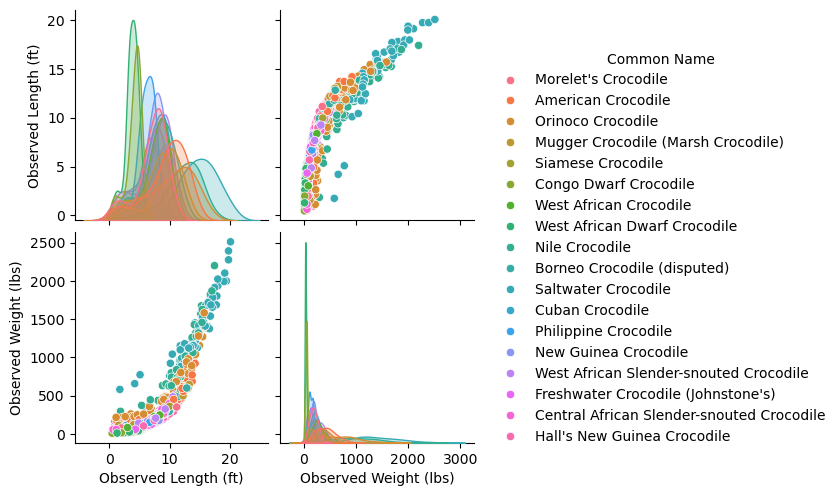

```python
plt.figure(figsize=(12, 6))
sns.pairplot(crocodile_data,
             vars=["Observed Length (ft)", "Observed Weight (lbs)"],
             hue="Common Name")
plt.show()
```

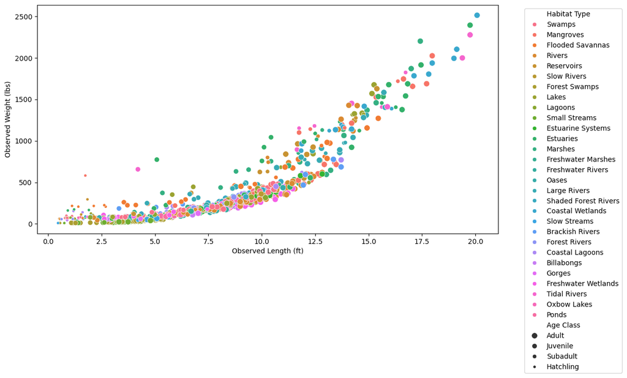

```python
plt.figure(figsize=(12, 6))
sns.scatterplot(
    data=crocodile_data,
    x="Observed Length (ft)", y="Observed Weight (lbs)",
    hue="Habitat Type", size="Age Class"
)
plt.legend(bbox_to_anchor=(1.05, 1), loc="upper left")
plt.show()
```

```python
species_by_length = crocodile_data_cleaned.groupby("Common Name")["Observed Length (ft)"].max().sort_values(ascending=False)
species_by_length
```

```
Common Name
Saltwater Crocodile                          20.078741
Nile Crocodile                               17.421260
Orinoco Crocodile                            15.780840
American Crocodile                           14.206037
Mugger Crocodile (Marsh Crocodile)           13.221785
Borneo Crocodile (disputed)                  12.828084
Hall's New Guinea Crocodile                  11.450132
West African Slender-snouted Crocodile       11.187664
Morelet's Crocodile                          11.154856
Cuban Crocodile                              11.089239
New Guinea Crocodile                         11.089239
West African Crocodile                       10.990814
Siamese Crocodile                            10.564305
Central African Slender-snouted Crocodile    10.039370
Freshwater Crocodile (Johnstone's)            9.383202
Philippine Crocodile                          8.595801
Congo Dwarf Crocodile                         5.807087
West African Dwarf Crocodile                  5.380578
Name: Observed Length (ft), dtype: float64
```

```python
largest_three_species = species_by_length.head(3).index.tolist()
smallest_three_species = species_by_length.tail(3).index.tolist()
```

```python
big_crocs = crocodile_data_cleaned[crocodile_data_cleaned["Common Name"].isin(largest_three_species)]
big_crocs
```

|  | Scientific Name | Common Name | Observed Length (ft) | Observed Weight (lbs) | Age Class | Sex | Habitat Type |
| --- | --- | --- | --- | --- | --- | --- | --- |
| 2 | Crocodylus intermedius | Orinoco Crocodile | 3.543307 | 260.586084 | Juvenile | Unknown | Flooded Savannas |
| 17 | Crocodylus niloticus | Nile Crocodile | 14.337271 | 1245.610300 | Adult | Female | Reservoirs |
| 19 | Crocodylus porosus | Saltwater Crocodile | 5.085302 | 773.601158 | Juvenile | Male | Estuaries |
| 21 | Crocodylus niloticus | Nile Crocodile | 15.255906 | 1675.070276 | Adult | Male | Lakes |
| 24 | Crocodylus niloticus | Nile Crocodile | 10.433071 | 754.200502 | Juvenile | Male | Marshes |
| ... | ... | ... | ... | ... | ... | ... | ... |
| 963 | Crocodylus intermedius | Orinoco Crocodile | 11.089239 | 684.093586 | Adult | Unknown | Flooded Savannas |
| 966 | Crocodylus niloticus | Nile Crocodile | 15.354331 | 1458.797054 | Adult | Female | Marshes |
| 970 | Crocodylus niloticus | Nile Crocodile | 6.791339 | 445.994626 | Juvenile | Unknown | Lakes |
| 974 | Crocodylus intermedius | Orinoco Crocodile | 5.675853 | 258.381464 | Juvenile | Unknown | Flooded Savannas |
| 991 | Crocodylus niloticus | Nile Crocodile | 10.269029 | 630.080396 | Subadult | Male | Reservoirs |

164 rows × 7 columns

```python
small_crocs = crocodile_data_cleaned[crocodile_data_cleaned["Common Name"].isin(smallest_three_species)]
smallest_three_species
```

```
['Philippine Crocodile',
 'Congo Dwarf Crocodile',
 'West African Dwarf Crocodile']
```

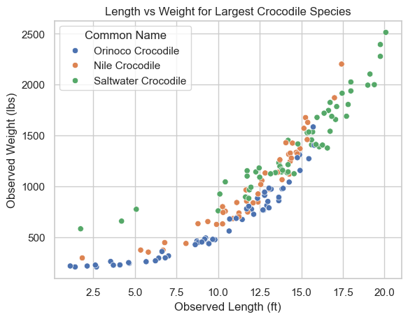

```python
sns.scatterplot(
    data=big_crocs,
    x="Observed Length (ft)",
    y="Observed Weight (lbs)",
    hue="Common Name"
)
plt.title("Length vs Weight for Largest Crocodile Species")
plt.show()
```

Here I've visualized the three species of crocs with the largest lengths. I realized the trend and chart is going to look similar when using both Weight and Length, so what if I keep one of those features and include Age Class?

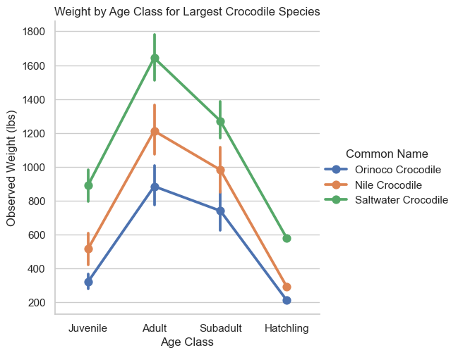

```python
sns.set_theme(style="whitegrid")
sns.catplot(
    data=big_crocs,
    kind="point", # yay a solid one thats easy to read
    x="Age Class",
    y="Observed Weight (lbs)",
    hue="Common Name"
)
plt.title("Weight by Age Class for Largest Crocodile Species")
plt.show()
```

Now lets split my data into my X (features) and y (label) so we can start evaluating and training our model.

```python
X = crocodile_data_cleaned[features]
y = crocodile_data_cleaned["Scientific Name"]
```

Now I will evaluate how my model generalizes.

```python
from sklearn.model_selection import train_test_split
```

```python
X_train, X_test, y_train, y_test = train_test_split(X, y, test_size=0.2, train_size=0.8, random_state=42, stratify=y)
```